# miRNA target enrichment analysis with enrichMiR

Pierre-Luc Germain and Michael Soutschek

D-HEST Institute for Neuroscience, ETH  
Lab of Statistical Bioinformatics, UZH  
Lab of Systems Neuroscience, D-HEST Institute for Neuroscience, ETH

17 February 2022

#### Abstract

This vignettes explores the main functionalities of the enrichMiR package.

#### Package

enrichMiR 0.99.16

# Contents

[figure not shown]

## 0.1 Installing

You can install the package using:

```r
BiocManager::install("ETHZ-INS/enrichMiR")
```

## 0.2 Preparing the data

EnrichMiR requires two main inputs: a target annotation object, and the signal in which you want to look for target enrichment, such as a geneset (versus a background set) or the results of a differential-expression analysis (DEA). Genesets would simply be vectors of gene identifiers, while a DEA would be a table that looks like this:

```r
library("enrichMiR")
data("exampleDEA",package="enrichMiR")
head(exampleDEA)
```

```
##            logFC       PValue          FDR
## TXLNA  -1.229066 3.141602e-21 6.068005e-17
## CERS2  -1.542478 1.373871e-19 8.845438e-16
## CNOT9  -1.097465 4.592100e-19 1.773928e-15
## NR6A1  -1.759071 3.920603e-19 1.773928e-15
## LASP1  -1.683993 7.219226e-19 2.323989e-15
## TAGLN2 -1.929537 4.468201e-17 1.078791e-13
```

The row names should be gene identifiers (or also transcript identifiers, depending on the target annotation), and it should minimally have the ‘logFC’, ‘PValue’ and ‘FDR’ columns (similar column names from established RNAseq DEA packages can be automatically recognized).

The other important input is a target annotation, which looks like this:

```r
# we load the TargetScan conserved target annotation for human:
data("consTShs", package="enrichMiR")
consTShs[,1:4]
```

```
## DataFrame with 109556 rows and 4 columns
##             set  feature     sites     score
##        <factor> <factor> <integer> <numeric>
## 1       UGGCACU KIAA2022         3    -0.604
## 2       UGGCACU TBX15            1    -0.552
## 3       ACAGUAC MAPK1            2    -0.279
## 4       UGGCACU MAPK1            1    -0.262
## 5       UGGCACU SMPD3            1    -0.290
## ...         ...      ...       ...       ...
## 109552  AAGUCAC    RPAP2         1    -0.001
## 109553  GUGACUG    RPAP2         1    -0.002
## 109554  UUAUUGA    RPAP2         2    -0.007
## 109555  UCAACAC    NAA60         1    -0.149
## 109556  UCAACAG    NAA60         1    -0.010
```

A target annotation minimally has the columns “set” (indicating the sets to be tested, in this case the miRNA families, denoted by their seed region) and  
“feature” (the features for which enrichment is tested, such as genes), together denoting a miRNA-target pair, and optionally the columns “sites” (indicating how many binding sites the feature has for the miRNA) and “score” indicating for instance a repression score. (The objects can also include metadata regarding synonymous feature names and miRNA family members).

# 1 Running an enrichment analysis

An enrichment analysis can be launched as follows:

```r
devtools::load_all("../")
```

```
## ℹ Loading enrichMiR
```

```r
er <- testEnrichment(exampleDEA, consTShs)
```

```
## Preparing inputs...
```

```
## Running the following tests: siteoverlap, areamir
```

Unless the tests are specified, this will run the default tests, namely the siteoverlap test respectively on significantly upregulated and downregulated genes, as well as the areamir test on the continous differential expression signal. Printing the object will give an overview of the top results of each test:

```r
er
```

```
## An `enrich.results` object with the following analyses:
```

```
## $siteoverlap.down
##         enrichment       pvalue          FDR
## UGGUCCC      3.108 2.076829e-46 4.485951e-44
## UUGGUCC      2.334 2.083233e-28 2.249891e-26
## CUGGACU      1.533 1.470018e-03 9.409740e-02
## GAGGGGC      1.576 1.742544e-03 9.409740e-02
## UUGGCAC      0.646 3.819316e-03 1.649945e-01
## CCCCUGG      1.366 5.348543e-03 1.925475e-01
##
## $siteoverlap.up
##         enrichment       pvalue       FDR
## GUGCAAA      1.146 0.0006421866 0.1387123
## UCACAUU      1.013 0.0026260039 0.2836084
## ACAUUCA      0.886 0.0061618563 0.3894351
## UCAUAGA      1.899 0.0072117620 0.3894351
## UAAUGCU      1.279 0.0138413141 0.4830110
## GCUACAU      1.336 0.0151850705 0.4830110
##
## $areamir
##         enrichment       pvalue          FDR
## UGGUCCC   8.608218 7.420491e-18 1.498939e-15
## UUGGUCC   6.591270 4.360788e-11 8.765183e-09
## CAGUAGU  -2.762515 5.735789e-03 1.000000e+00
## AUUGCAC  -2.671043 7.561601e-03 1.000000e+00
## GAGGGGC   2.567848 1.023320e-02 1.000000e+00
## UAAUGCU  -2.414134 1.577265e-02 1.000000e+00
```

We see that both the siteoverlap test on downregulated genes and the areamir test give the same top enrichments, while the siteoverlap test on upregulated genes gives no enrichment. An aggregated table for all tests can also be obtained using `getResults(er)`, and more detailed results of a test can be viewed with:

```r
er$siteoverlap.down
```

```
## DataFrame with 216 rows and 9 columns
##                        members set_size   overlap sites.overlap enrichment
##                    <character>  <table> <integer>     <numeric>  <numeric>
## UGGUCCC      hsa-miR-133a-3p.1      264        84            94      3.110
## UUGGUCC hsa-miR-133a-3p.2;hs..      339        72            85      2.330
## CUGGACU hsa-miR-378a-3p;hsa-..       94        13            14      1.530
## GAGGGGC hsa-miR-3184-5p;hsa-..       83        10            13      1.580
## UUGGCAC hsa-miR-1271-5p;hsa-..      509        40            50      0.646
## ...                        ...      ...       ...           ...        ...
## GGACGGA            hsa-miR-184       16         0             0     -0.139
## UAGACUG        hsa-miR-151a-3p       56         0             0     -1.830
## UGUGCGG           hsa-miR-147b        8         0             0      0.861
## UGUGCGU         hsa-miR-210-3p       15         0             0     -0.493
## UUUGCGA        hsa-miR-450a-5p        5         0             0      1.450
##            pvalue       FDR                  genes.down              genes.up
##         <numeric> <numeric>                <FactorList>          <FactorList>
## UGGUCCC  2.08e-46  4.49e-44 ADCY6  ,ALDH5A1,ARFIP2 ,...
## UUGGUCC  2.08e-28  2.25e-26 ADCY6  ,AIF1L  ,ALDH5A1,...           PHTF2,SESN3
## CUGGACU  1.47e-03  9.41e-02 ANKRD52,ARL10  ,CDCA7L ,...         SLC2A3,ZNF652
## GAGGGGC  1.74e-03  9.41e-02 ANKRD52,ATP8B2 ,BAZ2A  ,...
## UUGGCAC  3.82e-03  1.65e-01 ADCY6  ,AHCYL1 ,ANKRD52,... AGO4 ,ATXN1,BRWD1,...
## ...           ...       ...                         ...                   ...
## GGACGGA         1         1                                              AGO2
## UAGACUG         1         1                                              AGO2
## UGUGCGG         1         1                                             MEF2A
## UGUGCGU         1         1                                             MEF2A
## UUUGCGA         1         1
```

The results can alternatively be visualized with the `enrichPlot` function:

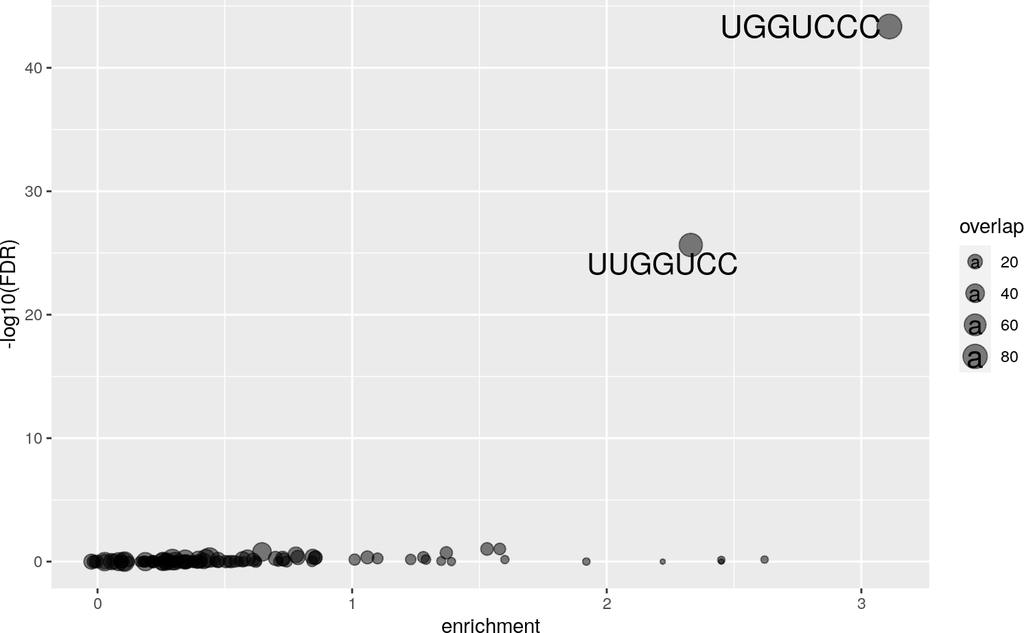

```r
enrichPlot(er$siteoverlap.down)
```

# 2 CD plots

A good way to visualize an enrichment is to plot the cumulative foldchange distributions of different target groups. This can be done with the `CDplotWrapper` function:

```
## Preparing inputs...
```

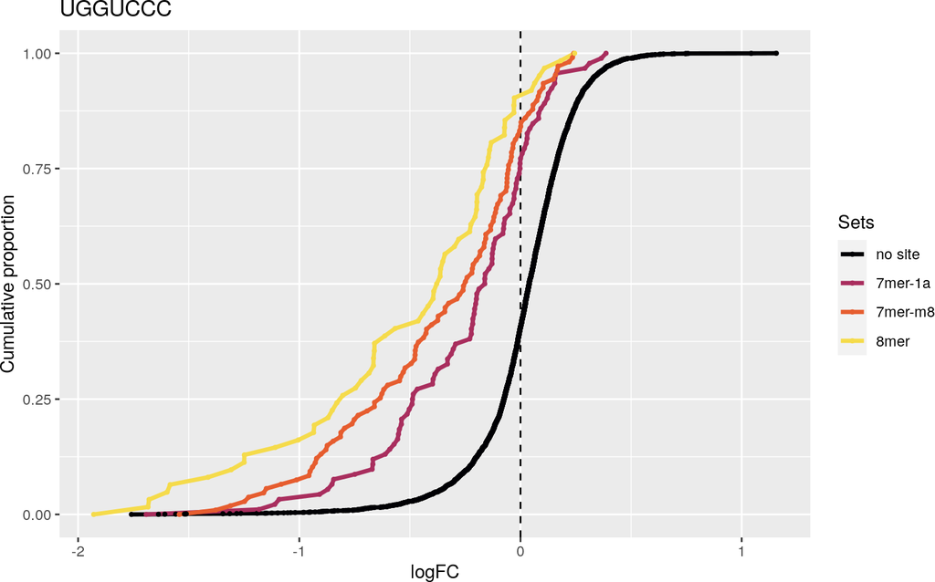

```r
CDplotWrapper(dea=exampleDEA, sets=consTShs, setName="UGGUCCC")
```

The genes in each sets are ranked according to their foldchange (the x-axis), while the y-axis shows the proportion of genes in the set that have a foldchange below or equal to that given on x. In this way, small shifts in foldchanges can easily be visualized.

In the presence of a real miRNA effect, we expect to see a gradual dose-response pattern, as shown above, meaning that targets with stronger binding sites also have stronger log-foldchanges (i.e. lower logFC, in the case of an increased miRNA activity, as in this example).

There are different ways of splitting the genes into groups, which can be specified using the `by` argument:

```
## Preparing inputs...
```

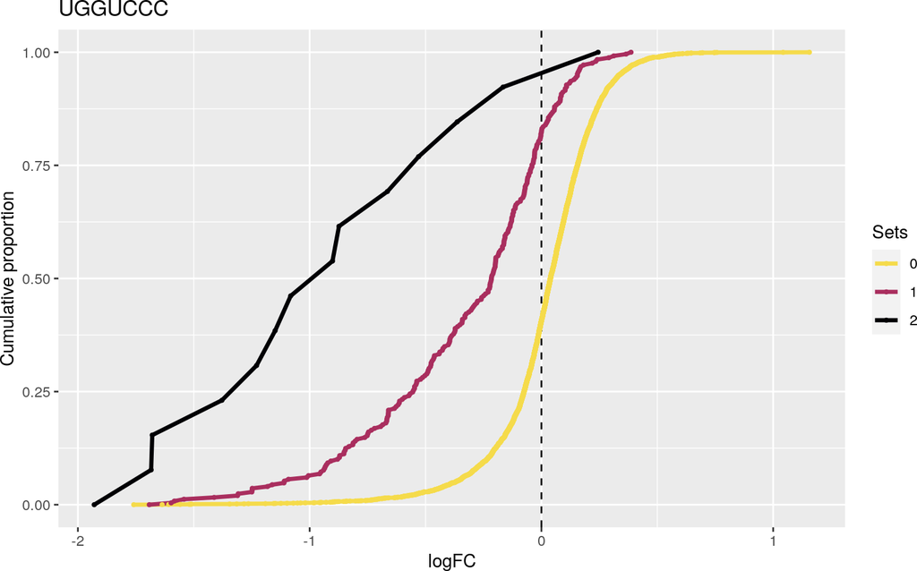

```r
CDplotWrapper(dea=exampleDEA, sets=consTShs, setName="UGGUCCC", by="sites")
```

Because UTR length is correlated with more binding sites for any miRNA, the number of sites tends to give spurious signals. We therefore recommend splitting by best binding type if this information is available in the target annotation you are using, or otherwise splitting by predicted repression score (if available).

# 3 Overview of the different enrichment tests

enrichMiR implements different statistical tests for target enrichment. You can view what tests are possible for a given input using:

```r
availableTests(exampleDEA, consTShs)
```

```
##  [1] "areamir"     "ebayes"      "gsea"        "ks"          "lmadd"
##  [6] "modscore"    "modsites"    "mw"          "overlap"     "regmir.bb"
## [11] "regmir.bc"   "regmir.cc"   "siteoverlap" "woverlap"
```

Some tests depend on continous inputs (e.g. fold-changes), and hence require the results of a differential expression analysis (DEA) to be provided), while others are binary, i.e. based on the membership in a gene set. When the input is a DEA, each binary tests will be performed on both significantly upregulated and downregulated genes.

Below is a description of the various enrichment tests. We recommend using the siteoverlap (most sensitive) or areamir tests. For a more detailed benchmark, please consult the publication.

### Description of the enrichment tests

Several target enrichment tests were benchmarked (results in the benchmark tab), and are described below. The best overall tests were selected as default for the app, and although other implemented tests are made available in the app's advanced options, their usage is not recommended.

The tests differ in the inputs they use, both in terms of the target annotation as well as of the type of signal in which enrichment is looked for. On the signal side, tests denoted as 'binary' compare features (genes or transcripts) in a given set (e.g. your significantly downregulated genes) to those in a background set (i.e. over-representation analysis), whereas tests denoted as 'continuous' instead rely on a numeric input signal, such as the mangitude or significance of changes in an input differential expression analysis (by default, the tests use the sign of the foldchange multiplied by the -log10(FDR), which is well correlated to logFC for genes with low intra-group variability, and more robust than the latter). On the annotation side, tests can also either use set membership (i.e. whether or not a given feature is a predicted miRNA target) or numeric values, such as the number of binding sites harbored by a given feature, or a repression score (i.e. the extent to which a given feature is predicted to be repressed by a miRNA).

As is the case for over-representation analysis in general, for tests based on binary inputs the choice of a good background is critical. In many contexts, the background set of genes will be the set of genes expressed in the system of interest.

#### Default tests

- - **siteoverlap** (binary signal, set membership):  
    The siteoverlap test is based on Fisher's exact test, but using the number of sites on predicted targets and in the background instead of counting each feature as one. While in theory this violates the assumption of independence of the counts (since all the binding sites of a given transcript are either in or out of the set), leading to slightly anti-conservative p-values, in practice this test is excellent at identifying the most enriched miRNA.
  - **areamir** (continuous signal, score or set membership):  
    The areamir test is based on the analytic Rank-based Enrichment Analysis (aREA) test implemented in the 'msviper' function of the [viper](https://www.bioconductor.org/packages/devel/bioc/html/viper.html) package. The test is akin to an analytical version of GSEA (see below), but it can additionally use degrees or likelihood of set membership. If repression scores are available in the annotation, areamir will therefore use a (trimmed) version of it as set membership likelihood.

##### Other tests implemented and evaluated

- - **overlap** (binary signal, set membership):  
    This test is based on Fisher's exact test, using the number of features (i.e. transcripts/genes) among predicted targets vs in the background (and therefore ignoring any site-based information).
  - **woverlap** (binary signal, set membership):  
    This test is like the above 'overlap' test, but corrects for UTR length using the Wallenius method, as implemented in the [goseq](https://www.bioconductor.org/packages/devel/bioc/html/goseq.html) package.
  - **Mann-Whitney (MW)** (continuous signal, set membership):  
    This is the Mann-Whitney (also known as Wilcoxon) non-parametric test comparing targets and non-targets.
  - **Kolmogorov-Smirnov (KS)** (continuous signal, set membership):  
    This is the Kolmogorov-Smirnov test comparing the signal distribution of targets vs non-targets.
  - **Combined Kolmogorov-Smirnov (KS2)** (continuous signal, set membership):  
    This is similar to the Kolmogorov-Smirnov test, but compares upregulated and downregulated genes separately, expecting the direction of the distribution shift to be consistent between the two, and if so combining the p-values using Fisher's method. This excludes distributional changes that are inconsistent with changes in miRNA activity, and leads to improved results over the traditional KS test.
  - **modscore** (continuous signal, repression score):  
    This is a linear regression testing the relationship between the input signal and the corresponding repression score predicted for a given miRNA.
  - **ebayes** (continuous signal, repression score):  
    This is akin to the `modscore` tests, but performed using limma's moderated t-statistics.
  - **modsites** (continuous signal, number of sites):  
    This is a linear regression testing the relationship between the input signal and the number of predicted binding sites for a given miRNA, correcting for UTR length.
  - **GSEA** (continuous signal, set membership)  
    This test uses the multi-level fast GeneSet Enrichment Analysis (GSEA) implemented in the [fgsea](https://www.bioconductor.org/packages/devel/bioc/html/fgsea.html) package, which is highly successful for Gene Ontology enrichment analysis. In the context of our benchmark, however, it performed very poorly.
  - **regmir**  
    The regmir test uses constrained lasso-regularized regression, which has a high specificity but lower sensitivity. The test will use binary or continuous inputs (using then either linear or binomial regression), as well as binary set membership or predicted repression score, depending on the availability of the input. The binary version of the test has shown the best performances.